# Activity 1.2 - RStudio and R Markdown

Adam Weaver

8/29/2019

### Load packages

```r
library(tidyverse)
library(datasauRus)
```

### Exercise 1

Based on the help file, the `datasaurus_dozen` file contains 1846 rows of data and 3 columns of information stored per row. The variables included in the data frame are a “dataset” variable, which indicates which of the 13 datasets a particular row is from, and x and y values, so that each row can be place on a coordinate plane.

### Exercise 2

The following code allows us to first filter the total data in the `datasaurus_dozen` file to include just the `dino` data set, then plot y vs. x for the remaining data:

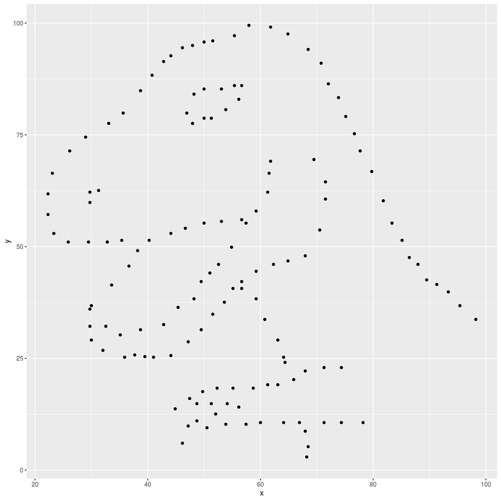

```r
dino_data <- datasaurus_dozen %>%
  filter(dataset == "dino")

ggplot(data = dino_data, mapping = aes(x = x, y = y)) +
  geom_point()
```

As the name of the data set suggests, the `dino` dataset, when plotted, yields a graph that is of an image of a dinosaur.

The following code allows us to calculate the correlation coefficient between y and x for the `dino` dataset, which we stored as `dino_data` after filtering the original data for just the `dino` dataset in the previous code:

```r
dino_data %>%
  summarize(r = cor(x, y))
```

```
## # A tibble: 1 x 1
##         r
##     <dbl>
## 1 -0.0645
```

Because the correlation coefficient is extremely close to zero, it appears there is no meaningful correlation between x and y for the `dino` dataset. Considering that the data is intended to plot the shape of a dinosaur, and not represent any particular function, that should not be surprising.

### Exercise 3

To plot the `star` dataset, we can use almost the same code as we did to plot the `dino` dataset, with the notable difference of replacing any mentions of the `dino` dataset with the `star` dataset to access the new, desired dataset. The following code is the result of doing just that:

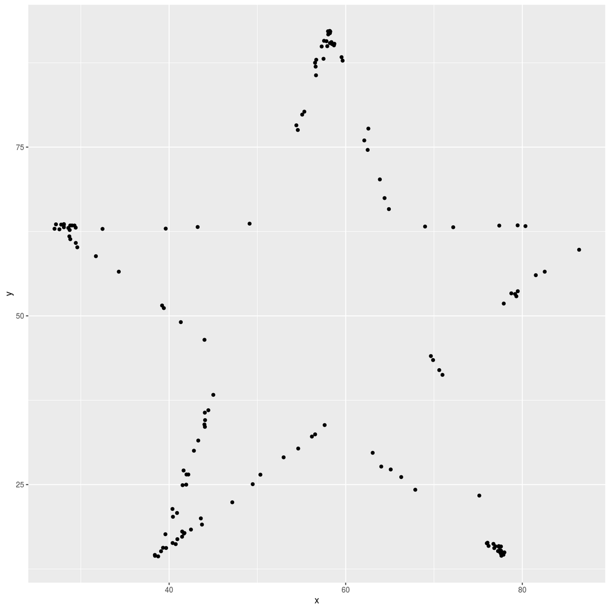

```r
star_data <- datasaurus_dozen %>%
  filter(dataset == "star")

ggplot(data = star_data, mapping = aes(x = x, y = y)) +
  geom_point()
```

Once again, the name of the data set gives us a pretty clear idea of what it is meant to look like. The `star` dataset, then, graphs in the shape of a star.

Now, to calculate the correlation coefficient for the `star` dataset, we can make the same changes as described above to the corresponding code we used for the `dino` dataset, as follows:

```r
star_data %>%
  summarize(r = cor(x, y))
```

```
## # A tibble: 1 x 1
##         r
##     <dbl>
## 1 -0.0630
```

Again, since the data is meant to plot in the shape of a star, x and y have no real correlation, and the correlation coefficient is very close to zero.

### Exercise 4

To plot the data in the `circle` dataset, we can change out any mentions of “star” in the code from the previous exercise with “circle.” The following code will plot y vs. x for the `circle` dataset.

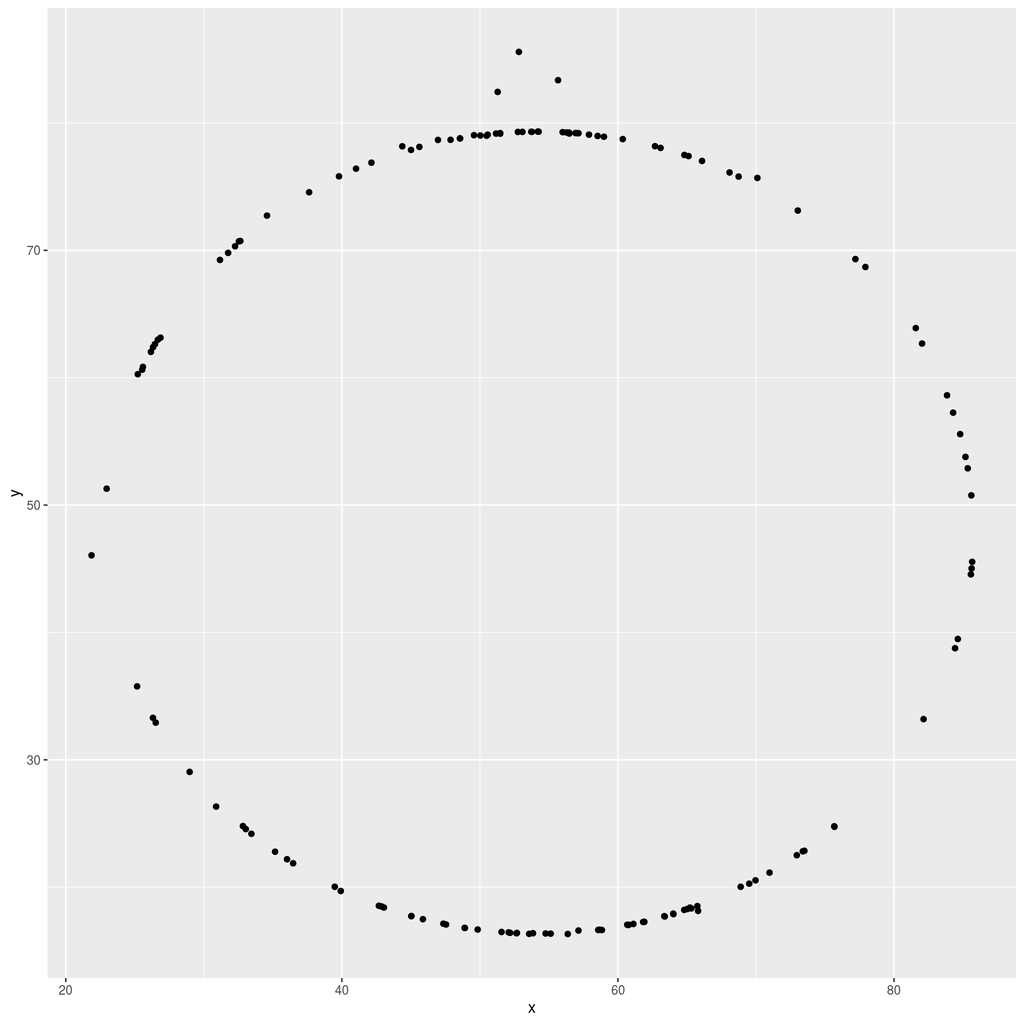

```r
circle_data <- datasaurus_dozen %>%
  filter(dataset == "circle")

ggplot(data = circle_data, mapping = aes(x = x, y = y)) +
  geom_point()
```

The resulting graph takes on the shape of a circle, though it appears there is a bit of outlying data with greater than average y values at roughly the median value for x.

To calculate the correlation coefficient for this data set, we can once again use nearly identical code to that which we used for the `star` data set, swapping in the newly-created `circle_data` in place of the old `star_data`, which results in the following code:

```r
circle_data %>%
  summarize(r = cor(x, y))
```

```
## # A tibble: 1 x 1
##         r
##     <dbl>
## 1 -0.0683
```

The resulting *r* value from the above calculation is almost equal to the value we calculated back in Exercise 2 with the `dino` dataset. This makes sense, as neither a circle nor a dinosaur shape would fit well with most forms of regression functions.

### Exercise 5

To plot all the datasets at once, we can use the following code:

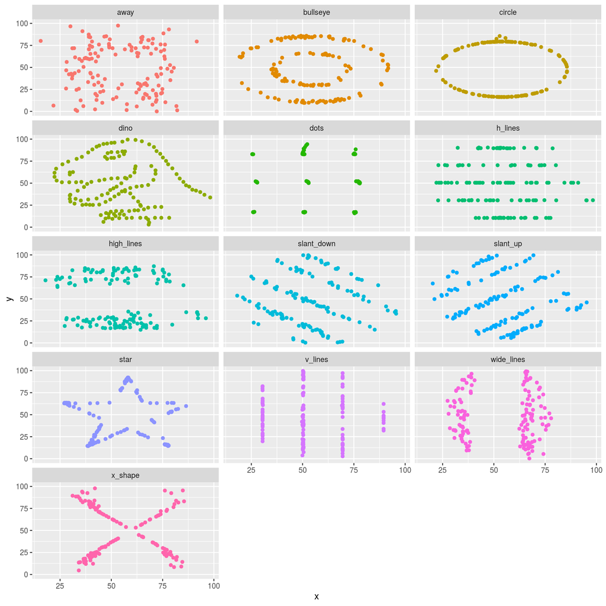

```r
ggplot(data = datasaurus_dozen, aes(x = x, y = y, color = dataset)) +
  geom_point() +
  facet_wrap(~ dataset, ncol = 3) +
  theme(legend.position = "none")
```

This code generates an individual plot for each dataset, while also removing the legend that would otherwise appear. It also makes each individual dataset graph in its own color.

To get the correlation coefficients, we can use the same calculation as we have in the previous exercises. But to get the correlation coefficients for all of the data, we need to have the code first pull from the datasaurus_dozen file as a whole, rather than just the specific desired dataset, then tell it to group like dataset rows so we get relevant results per dataset, and finally print all 13 lines. The following code does exactly that:

```r
datasaurus_dozen %>%
  group_by(dataset) %>%
  summarize(r = cor(x, y)) %>%
  print(13)
```

```
## # A tibble: 13 x 2
##    dataset          r
##    <chr>        <dbl>
##  1 away       -0.0641
##  2 bullseye   -0.0686
##  3 circle     -0.0683
##  4 dino       -0.0645
##  5 dots       -0.0603
##  6 h_lines    -0.0617
##  7 high_lines -0.0685
##  8 slant_down -0.0690
##  9 slant_up   -0.0686
## 10 star       -0.0630
## 11 v_lines    -0.0694
## 12 wide_lines -0.0666
## 13 x_shape    -0.0656
```

As we can see, all the data sets result in a correlation coefficient of nearly 0. This is because regression functions do not fit well with the shapes and patterns most of the data sets make. Even the data sets that trace linear shapes do not fit regression well, because the data is still scattered and spread widely, albeit into multiple lines.